# DATA_ANALYSIS_PROJECT_1(ANALYSIS_1)

```python
import numpy as np
import pandas as pd
import matplotlib.pyplot as plt
import scipy as s
from scipy import stats as ss
import seaborn as sns
```

```python
ds1=pd.read_csv("after_cleaning_autos_data_set_file.csv")
```

```python
ds1
```

|  | dateCrawled | name | seller | offerType | price | abtest | vehicleType | yearOfRegistration | gearbox | powerPS | model | kilometer | monthOfRegistration | fuelType | brand | notRepairedDamage | dateCreated | nrOfPictures | postalCode | lastSeen |
| --- | --- | --- | --- | --- | --- | --- | --- | --- | --- | --- | --- | --- | --- | --- | --- | --- | --- | --- | --- | --- |
| 0 | 2016-03-24 11:52:17 | Golf_3_1.6 | Privat | Angebot | 480 | Test | Limousine | 1993 | Manuell | 0 | Golf | 150000 | 3 | Benzin | Volkswagen | Nein | 2016-03-24 | 0 | 70435 | 2016-04-07 03:16:57 |
| 1 | 2016-03-24 10:58:45 | A5_sportback_2.7_tdi | Privat | Angebot | 18300 | Test | Coupe | 2011 | Manuell | 190 | A4 | 125000 | 5 | Diesel | Audi | Ja | 2016-03-24 | 0 | 66954 | 2016-04-07 01:46:50 |
| 2 | 2016-03-14 12:52:21 | Jeep_grand_cherokee_"overland" | Privat | Angebot | 9800 | Test | Suv | 2004 | Automatik | 163 | Grand | 125000 | 8 | Diesel | Jeep | Nein | 2016-03-14 | 0 | 90480 | 2016-04-05 12:47:46 |
| 3 | 2016-03-17 16:54:04 | Golf_4_1_4__3türer | Privat | Angebot | 1500 | Test | Kleinwagen | 2001 | Manuell | 75 | Golf | 150000 | 6 | Benzin | Volkswagen | Nein | 2016-03-17 | 0 | 91074 | 2016-03-17 17:40:17 |
| 4 | 2016-03-31 17:25:20 | Skoda_fabia_1.4_tdi_pd_classic | Privat | Angebot | 3600 | Test | Kleinwagen | 2008 | Manuell | 69 | Fabia | 90000 | 7 | Diesel | Skoda | Nein | 2016-03-31 | 0 | 60437 | 2016-04-06 10:17:21 |
| ... | ... | ... | ... | ... | ... | ... | ... | ... | ... | ... | ... | ... | ... | ... | ... | ... | ... | ... | ... | ... |
| 367537 | 2016-03-21 09:50:58 | Mitsubishi_cold | Privat | Angebot | 0 | Control | Limousine | 2005 | Manuell | 0 | Colt | 150000 | 7 | Benzin | Mitsubishi | Ja | 2016-03-21 | 0 | 2694 | 2016-03-21 10:42:49 |
| 367538 | 2016-03-05 19:56:21 | Smart_smart_leistungssteigerung_100ps | Privat | Angebot | 1199 | Test | Cabrio | 2000 | Automatik | 101 | Fortwo | 125000 | 3 | Benzin | Smart | Nein | 2016-03-05 | 0 | 26135 | 2016-03-11 18:17:12 |
| 367539 | 2016-03-19 18:57:12 | Volkswagen_multivan_t4_tdi_7dc_uy2 | Privat | Angebot | 9200 | Test | Bus | 1996 | Manuell | 102 | Transporter | 150000 | 3 | Diesel | Volkswagen | Nein | 2016-03-19 | 0 | 87439 | 2016-04-07 07:15:26 |
| 367540 | 2016-03-20 19:41:08 | Vw_golf_kombi_1_9l_tdi | Privat | Angebot | 3400 | Test | Kombi | 2002 | Manuell | 100 | Golf | 150000 | 6 | Diesel | Volkswagen | Nein | 2016-03-20 | 0 | 40764 | 2016-03-24 12:45:21 |
| 367541 | 2016-03-07 19:39:19 | Bmw_m135i_vollausgestattet_np_52.720____euro | Privat | Angebot | 28990 | Control | Limousine | 2013 | Manuell | 320 | M_reihe | 50000 | 8 | Benzin | Bmw | Nein | 2016-03-07 | 0 | 73326 | 2016-03-22 03:17:10 |

367542 rows × 20 columns

```python
ds1.isnull().sum()
```

```
dateCrawled            0
name                   0
seller                 0
offerType              0
price                  0
abtest                 0
vehicleType            0
yearOfRegistration     0
gearbox                0
powerPS                0
model                  0
kilometer              0
monthOfRegistration    0
fuelType               0
brand                  0
notRepairedDamage      0
dateCreated            0
nrOfPictures           0
postalCode             0
lastSeen               0
dtype: int64
```

# What to do 👍(Client Questions)

## Analysis 1

## 1) Perform general Data analysis

Performing general data analysis involves several steps.Those are,

1.Data Collection:

```
-Obtain the dataset from a reliable source. This could be in the form of a CSV file.
```

2.Data Cleaning:

```
 - Check for missing values,inconsistencies in the data.
 - Handle missing data through imputation or removal.
 - Standardize data formats.
```

3.Exploratory Data Analysis (EDA):

```
 - Visualize the data using graphs, histograms, box plots, scatter plots etc.,
 - to understand the distribution,relationships and patterns.
 - Calculate summary statistics (mean, median, standard deviation, etc.) to describe the data.
```

4.Reporting:

```
 - Communicate the findings effectively, using visualizations, reports, or presentations.
```

## 2)Can you tell me the Distribution of Vehicles based on Year of Registration with the help of a plot

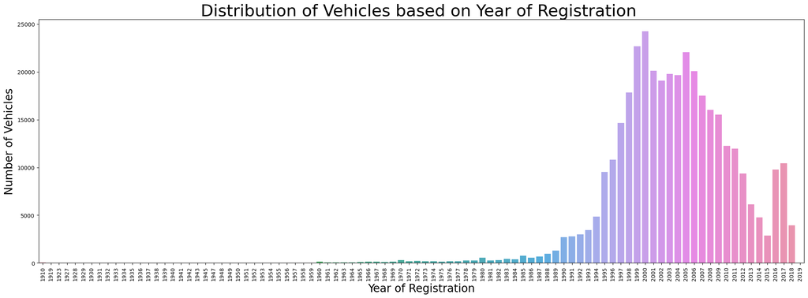

```python
plt.figure(figsize=(25,8))
sns.countplot(data=ds1, x="yearOfRegistration")
plt.title("Distribution of Vehicles based on Year of Registration ",size=30)
plt.xlabel("Year of Registration",size=20)
plt.ylabel("Number of Vehicles",size=20)
plt.xticks(rotation=90)            #rotate x-labels for better readability
plt.show()
```

## 3) Create a plot based on the Variation of the price range by the vehicle type

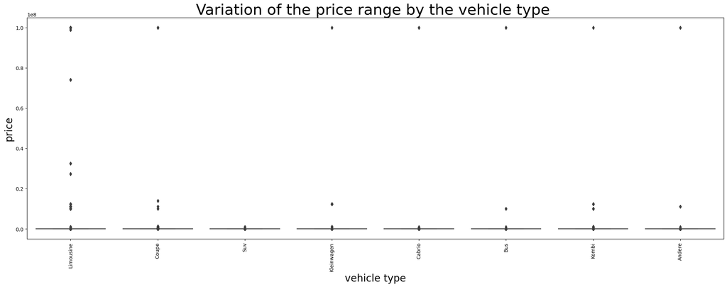

```python
plt.figure(figsize=(25,8))
sns.boxplot(data=ds1, x="vehicleType", y="price")
plt.title("Variation of the price range by the vehicle type ",size=30)
plt.xlabel("vehicle type",size=20)
plt.ylabel("price",size=20)
plt.xticks(rotation=90)            #rotate x-labels for better readability
plt.show()
```

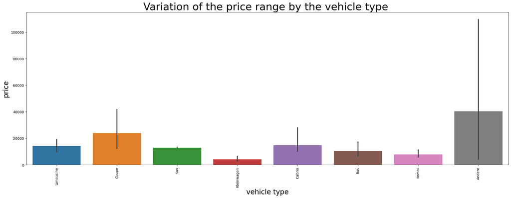

```python
plt.figure(figsize=(25,8))
a=sns.barplot(data=ds1, x="vehicleType", y="price")
plt.title("Variation of the price range by the vehicle type ",size=30)
plt.xlabel("vehicle type",size=20)
plt.ylabel("price",size=20)
plt.xticks(rotation=90)            #rotate x-labels for better readability
plt.show()
```

## 4) Find out Total count of vehicles by type available on ebay for sale.As well as create a visualization for the client

```python
ds1.vehicleType.value_counts()
```

```
Limousine     114818
Kleinwagen     95859
Kombi          68065
Bus            30129
Cabrio         22504
Coupe          18567
Suv            14510
Andere          3090
Name: vehicleType, dtype: int64
```

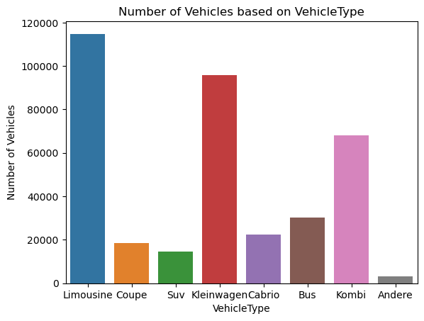

```python
sns.countplot(data=ds1, x='vehicleType')
plt.title('Number of Vehicles based on VehicleType')
plt.xlabel('VehicleType')
plt.ylabel('Number of Vehicles')
plt.show()
```

## 5) Is there any relationship between dollar_price and kilometer? (Explain with appropriate analysis)

```python
correlation = ds1['price'].corr(ds1['kilometer'])
correlation
```

```
-0.007683223435759035
```

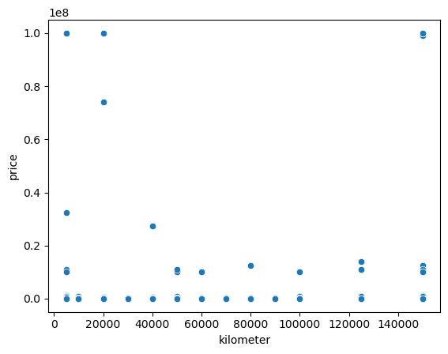

```python
sns.scatterplot(x='kilometer', y='price', data=ds1)
plt.show()
```

I can calculates the correlation coefficient between 'price' and 'kilometer'. The correlation value ranges from -1 to 1,

where:

- If the value is close to 1, it indicates a strong positive correlation.
- If the value is close to -1, it indicates a strong negative correlation.
- If the value is close to 0, it indicates no correlation.

The scatter plot visualizes the relationship between the two variables. If the points on the plot show a clear pattern, it suggests a relationship between the 'price' and 'kilometer'.

finally caluculated correlation coefficient is -0.0076 (approximately),then we will clarify that it indicates no correlation between "price" and "kilometer",because correlation coefficient is close to the 0.

```python
sns.heatmap(ds1,annot=True)
```

[output not shown]